# A general framework to run analyses in Santos et al.xxxxx

Gabriel Santos

2025-03-26 (16:02:18)

# 0 - Setting

```r
#Check package versions
#cbind(unlist(loadedNamespaces()),
#  unlist(lapply(
#   lapply(loadedNamespaces(),packageVersion),
#       as.character)))%>%
#       data.frame()%>%arrange(-desc(X1))%>%as_tibble()
```

# 1. Readme

The following script provide the general framework used to analyse demographic buffering continuum in Santos et al. in review:

Population responses to environmental stochasticity are primarily driven by survival-reproduction trade-offs and mediated by aridity

- Intermediary code and data steps are sourced along the framework
- Intermediary code and data include:
  - 1 - Data cleaning and selection and its intermediary data
  - 2 - Life history traits calculation and its intermediary data
  - 3 - Climatic variables calculation
  - 4 - Analyses with MCMCglmm
  - 5 - Core function: Stochastic elasticities of variance

# 2. Data selection and cleaning - COMPADRE, COMADRE & MOSAIC

- Script avaliable in “1 - Data cleaning and selection.R”
- Produce two datasets:
  - CleanData: Filter matrix singularity, presence of fecundity, individual matrices only
  - Supertree: extract supertree from MOSAIC database (Bernard et al. (2023))

```r
# Load cleaned data
CleanData<-readRDS("Data/CleanData.RDS")
supertree<-readRDS("Data/supertree.RDS")

Metadata<-CleanData$Metadata
MetadataClean<-CleanData$MetadataClean

#Reduce data to improve redability
MedatadaFinal<-MetadataClean%>%select(-c(lambda,Ecoregion,Binomial))
MedatadaFinal<-MedatadaFinal%>%
    left_join(.,
            Metadata%>%select(ID,StudyStart, StudyDuration, StudyEnd)%>%distinct(),
                by="ID")

rm(CleanData)   #Remove non-used data to improve memory usage
```

# 3. Life history traits (Calculate life history traits)

Script avaliable in “2 - Life history traits calculation.R”

- Produce:
  - dataset LHtraits.RDS:
  - Calculate life history traits and detect outliers

```r
#file.edit("2 - Life history traits calculation.R")
LHtraits<-readRDS("Data/LHtraits.RDS")
LHtraits
```

| ID | La | LaProb | e | D | Growth | H | mahal.dist | is.outlier |
| --- | --- | --- | --- | --- | --- | --- | --- | --- |
| Drc2.151_550 | -0.1380041113 | 1.086110513 | -0.05901093 | 0.670785792 | 0.569283047 | 0.427143199 | 1.293 | FALSE |
| Drc2.151_548 | -0.1120904829 | -0.198418968 | -0.05907052 | 0.494801325 | 0.655591333 | 0.712283977 | 1.510 | FALSE |
| Drc2.151_546 | -0.0797205365 | -0.941194722 | -0.05923442 | 0.683458564 | -0.010011845 | -0.757388211 | 2.854 | FALSE |
| Drc2.151_547 | -0.0742251260 | -0.944478284 | -0.05923672 | 0.740478128 | -0.280530601 | -0.914494150 | 3.275 | FALSE |
| Pnx2.399_1046 | -0.1249452534 | -0.704693154 | -0.05920869 | -0.384237106 | -1.263602230 | -0.273842809 | 2.884 | FALSE |
| Prm4.582_1157 | -0.0871013034 | 0.339904139 | -0.05843889 | -0.101927419 | -0.405338381 | 0.842929069 | 1.540 | FALSE |
| Trll.304_1438 | -0.0712299164 | -0.802265318 | -0.05893404 | 0.880116693 | -1.244750946 | 0.971863475 | 7.256 | FALSE |
| Trll.304_1442 | -0.1192825597 | -0.890646306 | -0.05913522 | 0.840366358 | -1.390493562 | 0.971863475 | 7.888 | FALSE |
| Trll.304_1445 | -0.1019075599 | -0.922024551 | -0.05907916 | 0.788866557 | -1.637620066 | 0.971863475 | 8.969 | FALSE |
| Trll.304_1446 | -0.0952340710 | -0.941512053 | -0.05905617 | 0.781769435 | -1.666755200 | 0.971863475 | 9.157 | FALSE |

[output cut: 278 more lines]

```r
## .. Filter outliers ----
spLHmat<-LHtraits%>%
    filter(is.outlier=="FALSE")%>%
        select(-c(is.outlier,mahal.dist))   %>%
column_to_rownames(var = "ID")

#Correlation plot - check colinearity
#spLHmat%>%cor()%>%corrplot::corrplot(.,title="Check Colinerarity on LH traits")
```

## 3.1 Fast-slow continuum / Life history PCA

- Perform PCA
- Check eigenvalues
- Plot eigenvalues and correlgram

```r
LHpca<-spLHmat%>%filter(complete.cases(.))%>%PCA(.,graph=FALSE,scale=TRUE) # Using raw data without imputatation

# LHpca - Map variables
LHpca$eig%>%t() #Explained variables
#LHpca$ind$coord    #Eigenvalues
dimdesc(LHpca, axes = 1:3, proba = 0.05)

# 2.2.Check PCA -----
cowplot::plot_grid(nrow=1,
  cowplot::plot_grid(ncol=1,
    fviz_eig(LHpca)+theme_bw(base_size=14),
    fviz_pca(LHpca, geom=c("point"))+theme_bw(base_size=14)
      ),
  LHpca$var$cor%>%
    ggcorrplot::ggcorrplot(method = "circle")+
    theme_bw(base_size=14)+theme(
      axis.text.x=element_text(angle=75,hjust=1)))+
      coord_fixed(ratio=.50)

#ggsave(file="Figures/PCALH.svg")


#Use Principal Components as variables - add to LHtraits
LHtraits<-left_join(by="ID",
    LHtraits,
      LHpca$ind$coord%>%data.frame()%>%
      rownames_to_column(var="ID")%>%as_tibble()%>%
    rename_with(., ~ gsub("Dim", "LHAxis", .x, fixed = TRUE))%>%
    select(ID,LHAxis.1:LHAxis.2))%>%
  filter(complete.cases(.))
```

# 4. Climate variables and environmental PCA

## 4.1. Extract and store climatic information

Extracted climatic data is available in `Data/Climate_df.RDS`

Because data download and information extraction is quite time consuming a dedicated Jupyter notebook to run on Google Colab is provided in: “ChelsaData Download and extraction - Google Colab.ipynb”

Run this Google Colab by typing in your brownser: https://githubtocolab.com/Ecosantos/Demogbuff-pops

```r
climate_df<-readRDS("Data/climate_df.RDS")
```

## 4.1. Analyse climatic timeseries, calculate environmental stochasticity and summarise information into a PCA

3 - Climatic variables calculation.R use the already extracted climatic data to:

- Data summary and metrics extraction described in methods
- Produce final dataset to analyse: “climate_df.RDS”
- Environmental trend, amplitude, and stochasticisticy

### 4.1.1. Checking collinearity and retaining climatic variables

```r
cor_matrix <- climate_df %>% select(-ID) %>% cor()
diag(cor_matrix) <- NA

# Find values higher than 0.65
high_corr <- which(abs(cor_matrix) > 0.65, arr.ind = TRUE)

# Output to selection
data.frame(
  Var1 = rownames(cor_matrix)[high_corr[, 1]],
  Var2 = colnames(cor_matrix)[high_corr[, 2]],
  Correlation = cor_matrix[high_corr]
) %>% arrange(desc(abs(Correlation)))

# Plot all variables to visualize collinearity
#climate_df%>%select(-ID)%>%
#  select(-c(Ampli_season_TMax,
#            Ampli_season_TMin,
#            Ampli_season_Prec))%>%
#  cor()%>%corrplot::corrplot()

## Retaining climatic variables -----
climate_df<-climate_df%>%select(
  -c(Mean_trend_TMin,
  Stoch_noisesize_TMin,Stoch_noisesize_Prec,
  Ampli_season_TMax,Ampli_season_TMin,Ampli_season_Prec))%>%
  as_tibble()
```

### 4.1.2. Climatic/environmental PCA

And its output

```r
# Produce the climatic/environmental PCA
ClimPCA<-climate_df%>%
mutate_at(vars(-c(ID)),scale)%>%
column_to_rownames("ID")%>%
#cor(.)%>%corrplot::corrplot(.)
PCA(.,graph=F,scale=FALSE)

#ClimPCA$ind$coord
ClimPCA$eig%>%t()   #Explained variables


cowplot::plot_grid(nrow=1,
cowplot::plot_grid(ncol=1,
fviz_eig(ClimPCA)+theme_bw(base_size=14),
fviz_pca(ClimPCA, geom=c("point"))+theme_bw(base_size=14)),
ClimPCA$var$cor%>%ggcorrplot::ggcorrplot(method = "circle")+theme_bw(base_size=14)+
  theme(axis.text.x=element_text(angle=75,hjust=1)))+
coord_fixed(ratio=.60)


#ggsave(file="Figures/PCAEnv.svg")

dimdesc(ClimPCA, axes = 1:3, proba = 0.05)
```

### 4.3 Mapping climatic axes

```r
Plot_clim<-Metadata%>%dplyr::select(.,c(ID,Lat,Lon))%>%
distinct(.,.keep_all=T)%>%
left_join(.,
data.frame(ClimPCA$ind$coord)%>%rownames_to_column(.,var="ID"),
by="ID")%>%
filter(complete.cases(.))%>%
mutate(across(Dim.1:Dim.3,scales::rescale,to=c(0,1)))

#Plot map
world <- map_data("world")

gmap<-ggplot() +
geom_map(
    data = world, map = world,
    aes(long, lat, map_id = region),
    color = "grey50", fill = "grey95", linewidth= 0.05)

gmap +
 geom_point(
    data = left_join(Plot_clim,distinct(MetadataClean,ID,.keep_all=T)%>%select(ID,Kingdom)),
    aes(x=Lon, y=Lat, fill = Dim.1,stroke=.3,size=Dim.2,shape=Kingdom))+
scale_shape_manual(values=c(23,21))+
scale_fill_viridis(option="magma")+
scale_size(range = c(1.5, 5))+
 theme_void()

#ggsave(file="Figures/ClimMap_all_taxa2.svg")
```

# 5. Calculate Demographic buffering From Vital Rates (Lower Level Parameters)

## 5.1. Sourcing main function used in this calculation

Main function calculates the stochastic elasticities within respect to variance of lower level vital rates

- This script creates the following functions:
  1. `My.vitalRatePerturbation`: produce the stochasticity elasticity with respect to variance.
     - This function is an adaptation of VitalRatePerturbation function in the `Rage` package (see Jones et al. (2022))
  2. `array_to_matrix`: an ancilliary function to transform timeseries of MPMs, usually returned as an array element to a timeserie of MPM in a object class matrix.

```r
source("MainFunction - Stochastic elasticities of variance lower level.R")
```

> Attention: Example where shrinking is possible in Animal - Alternation between reproductive non-reproductive stage - Reproductive estage <–> non-reproductive stage

```r
#filter(Metadata,ID=="Urs2.183_726")$mat
#lapply(filter(Metadata,ID=="Urs2.183_726")$mat,matA)

my.vitalRatePerturbation(
lapply(filter(Metadata,ID=="Urs2.183_726")$mat,matU),
lapply(filter(Metadata,ID=="Urs2.183_726")$mat,matF),
lapply(filter(Metadata,ID=="Urs2.183_726")$mat,matC))$`Lower-level Stochastic Elasticity with respect to the mean`
```

## 5.2. Derivating demograpic buffering in plants and animals

- Derivate demographic buffering in plants and animals
- Merge into a single dataframe

```r
# Quantify the number of populations with timeseries longer than three
unlist(MatRep)[unlist(MatRep)>2]%>%length()
```

### 5.2.2. Merging demographic buffering into a single data frame

```r
#'---------------------------------------------------------------------------
#       Merge Demographic buffering calculations in a single Data frame
#'---------------------------------------------------------------------------
ElasSigVR_full<-lapply(ElasSigVR,rownames_to_column, var = "VR")%>%
Map(cbind, ID = names(.), .)%>%
do.call(rbind,.)%>%
as_tibble()%>%
pivot_wider(names_from = VR,values_from=c(Mean,SD))%>%
filter(complete.cases(.))

ElasSigVR_data<-lapply(ElasSigVR,rownames_to_column, var = "VR")%>%
Map(cbind, ID = names(.), .)%>%
do.call(rbind,.)%>%
as_tibble()%>%
select(-SD)%>%              #Remove standard desviation
pivot_wider(names_from = VR,values_from=Mean)%>%
filter(complete.cases(.))


StochElasVR_data<-lapply(StochElasVR,rownames_to_column, var = "VR")%>%
Map(cbind, ID = names(.), .)%>%
do.call(rbind,.)%>%
as_tibble()%>%
select(-SD)%>%
pivot_wider(names_from = VR,values_from=Mean)%>%
filter(complete.cases(.))
```

### 5.2.3. Produce a definitive demographic buffering dataframe

This new data frame will be ready for merging with climatic data and life history traits

```r
databuff_data<-left_join(
ElasSigVR_data%>%setNames(paste0(names(.),'_SigElas')),
StochElasVR_data%>%setNames(paste0(names(.),'_Base')),
by=c("ID_SigElas"="ID_Base"))

databuff_data%>%glimpse()

MPMinfo<-data.frame(
 Buffmx=unlist(Buffmx),
  MatRep=unlist(MatRep),
   ID=uniqueID)%>%as_tibble()


databuff_data<-left_join(
 databuff_data,MPMinfo,
    by=c("ID_SigElas"="ID"))%>%
        filter(MatRep>2)%>%
          rename(ID="ID_SigElas")

#Comparing buffering in vital rates and life history traits
databuff_data%>%
left_join(.,LHtraits,by="ID")%>%
filter(complete.cases(.))%>%
select(-"ID")%>%cor()%>%corrplot::corrplot()
```

# 6. Merging all (Climatic data + Life history + Buffering)

```r
colnames(ClimPCA$ind$coord)<-gsub("Dim.", "ClimPC.", colnames(ClimPCA$ind$coord))
colnames(LHpca$ind$coord)<-gsub("Dim.", "LHPC.", colnames(LHpca$ind$coord))

LHpca_axes12<-LHpca$ind$coord[,c(1,2)]%>%data.frame()%>%rownames_to_column("ID")
ClimPCA_axes123<-ClimPCA$ind$coord[,c(1,2,3)]%>%data.frame()%>%rownames_to_column("ID")

merged_data<-databuff_data%>%
left_join(.,LHpca_axes12,by="ID")%>%
left_join(.,ClimPCA_axes123,by="ID")%>%
filter(complete.cases(.))%>%
left_join(.,MetadataClean,by="ID")%>%
distinct(ID,.keep_all=TRUE)


merged_data
```

Correlation plot

```r
merged_data%>%select_if(is.numeric)%>%cor()%>%corrplot::corrplot()
```

# 7. Building the super tree and make sure it works on phylogenetic analyses

- Check must return:
  - No duplicates
  - No polytomyes
  - Is.rooted == TRUE
  - is.binary == TRUE
  - is.ultrametric == TRUE
  - “any edge == 0” == FALSE

```r
#Make subtree
sppINphylo<-unique(merged_data$Binomial)[unique(merged_data$Binomial)%in%supertree$tip]

subtree<-keep.tip(supertree, sppINphylo)

#Check and Avoid duplicates
any(duplicated(subtree$node.label))
subtree<-makeNodeLabel(subtree); any(duplicated(subtree$node.label))

#Avoid polytomyes
subtree_backup<-subtree<-multi2di(subtree)


#Make sure branches are comparable, non-negative and non-zero
subtree$edge.length<-scales::rescale(subtree$edge.length,to=c(0.00001,.99999))

#Force ultrametric
subtree<-phytools::force.ultrametric(subtree, method="extend")

#Check if structure are kept
identical(subtree,subtree_backup)
all.equal.phylo(subtree,subtree_backup,use.edge.length=FALSE)

is.rooted(subtree)
is.binary(subtree)
is.ultrametric(subtree)
any(subtree$edge.length==0)
subtree$edge.length[subtree$edge.length==0]
```

# 8. Produce final dataset and phylogenetic analyses

```r
final_data<-merged_data%>%
mutate(phylo=Binomial)%>%
mutate(inPhylo=Binomial%in%sppINphylo)%>%
filter(inPhylo!=FALSE)%>%
select(-inPhylo)%>%
arrange(.,match(Binomial,subtree$tip))%>%
data.frame()
```

```r
final_data

#Total populations
print("Total pops"); (final_data%>%dim())[1]

#Total species
print("Total species"); final_data$SpeciesAccepted%>%unique()%>%length()

#Populations by kingdom
final_data%>%select(Kingdom)%>%table()

#Species by kingdom
final_data%>%select(SpeciesAccepted,Kingdom)%>%
distinct()%>%select(Kingdom)%>%table()

# USED MPMs
print("Total MPMs");filter(Metadata, ID %in% final_data$ID)$mat%>%length()
```

## 8.1. Prepare phylogenetic information associated

```r
PhyloSig_data<-final_data%>%
as_tibble()%>%
distinct(Binomial,.keep_all=TRUE)%>%
column_to_rownames("Binomial")%>%
select(is.numeric,Kingdom)%>%
select(-c(Clonality_Base,Clonality_SigElas))


PhyloSig_data_ANIMALS<-PhyloSig_data%>%filter(Kingdom=="Animalia")%>%select(-Kingdom)
PhyloSig_data_PLANTS<-PhyloSig_data%>%filter(Kingdom=="Plantae")%>%select(-Kingdom)
PhyloSig_data_ALL<-PhyloSig_data%>%select(-Kingdom)


subtree_Animals<-keep.tip(subtree, rownames(PhyloSig_data_ANIMALS))
subtree_Plants<-keep.tip(subtree, rownames(PhyloSig_data_PLANTS))
```

# 9. GLMM parameters & data imput

## 9.1. A separate dataset was created `data_model`

Data_model now includes absolute values of cumulativa_SigEla $| \sum E_v^\sigma |$.

```r
data_model<-final_data%>%select(-c(Reproduction_Base:Cumulative_Base))

data_model

#Transform CUMULATIVE IN ABSOLUTE VALUE
data_model$Cumulative_SigElas<-abs(data_model$Cumulative_SigElas)

#save(data_model,subtree_Animals,subtree_Plants,
#     file = "Data/GLMMdata.Rdata")
```

## 9.3. Determine the fixed effect of all models and response variables

Because we run multiple models representing the combination of several attributes (vital rates, ex. survival and reproduction) for the same fixed model, each element below is important to automatize the process

```r
# Determines the fixed effect component
fixEffect<-fixEffect<-"~LHPC.1 * LHPC.2 + ClimPC.1 * ClimPC.2 * ClimPC.3"

# Determines all variables of interest to make multiple models
InterestingVars<-c("Survival","Growth","Shrinking","Reproduction","Clonality","Buffmx","Cumulative")


traits<-traits_glmm<- unique (grep(paste(InterestingVars,collapse="|"),
                                   colnames(data_model), value=TRUE))
```

## 9.4. OPTIMIZING GLMM MODELS

Because we run several models with and without phylogenetic correction it take a long time to run in a in-house computer and a long script was created `5b - MCMCglmm run.R` . Moreover, to accelerate model performance and save time we also created a jupyter notebook that can use Google Collab computation `5b - MCMCglmm run.ipynb`

Most importantly, a partial output was created with the GLMM models in `Data/MCMCglmm_output.rds`.

Next steps use this partial output to reproduce the data.

# 10. Buffering paterns

```r
final_data_meta<-final_data%>%
left_join(.,MetadataClean%>%select(-lambda)%>%distinct(),by="ID")

final_data_meta
```

## 10.1 Ranking buffering

More and less buffered populations

```r
#-----------------------------------------------------------------------------------
#   RANKING BUFFERING
#-----------------------------------------------------------------------------------
ToRank<-final_data%>%
mutate(Cumulative_SigElas=abs(Cumulative_SigElas))%>%
group_by(Kingdom)%>%
select(ID,Cumulative_SigElas,SpeciesAccepted,AngioGymno,Class)%>%
  mutate(rank  = rank(Cumulative_SigElas, ties.method = "random"))

ToRank<-ToRank%>%
group_by(Kingdom)%>%
mutate(min=min(Cumulative_SigElas),
        max=max(Cumulative_SigElas))%>%
filter(rank==min(rank)|rank==max(rank))%>%
select(-c(min,max))%>%
left_join(.,Metadata%>%select(ID, CommonName,Family)%>%distinct(),by="ID")%>%
select(2,3,7,4,5,6,8,9)

ToRank%>%
left_join(.,ElasSigVR_full,by="ID")%>%mutate_if(is.numeric,round,3)%>%as.data.frame()
```

## 10.2. Animals and plants overlaps?

Yes!

```r
t.test(abs(final_data$Cumulative_SigElas)~final_data$Kingdom)
```

### Plot

```r
temp<-Stochslambs<-NULL
for(i in 1:length(unique(final_data$ID))){
temp<-filter(
    Metadata,ID==unique(final_data$ID)[i])$mat%>%
        matA()%>%
        stoch.growth.rate(.,maxt = 200,verbose = FALSE)
Stochslambs$approx[[i]]<-temp$approx
Stochslambs$sim[[i]]<-temp$sim
Stochslambs$CIlow[[i]]<-temp$sim.CI[[1]]
Stochslambs$CIhigh[[i]]<-temp$sim.CI[[2]]
#add verbose
    if (i == 1 || i%%40 == 0) {
              message("Calculating mean Matrices",
                 i)
    }
rm(temp)
}

Stochslambs_df<-data.frame(
    unique(final_data$ID),
        lapply(Stochslambs,cbind))%>%
    as_tibble()%>% unnest()%>%
        mutate_if(is.numeric,exp)%>%
    rename(., ID = unique.final_data.ID.)
```

An accessory function is necessary

```r
scientific_10 <- function(x) {
  parse(text=gsub("e", " %*% 10^", scales::scientific_format()(x)))
}
```

Plot

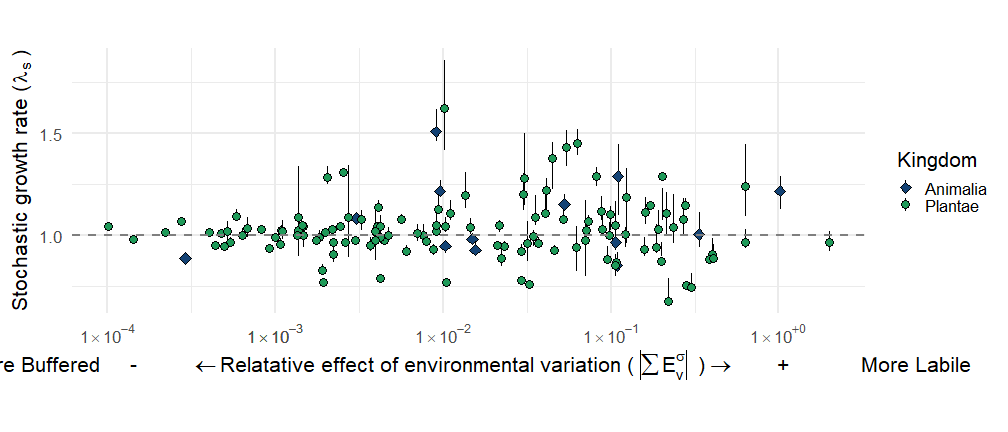

```r
final_data%>%
 select(ID:Cumulative_SigElas,Buffmx:MatRep,OrganismType,Kingdom,lambda)%>%
 pivot_longer(!c(ID,MatRep:lambda))%>%
 mutate(values=ifelse(value==0,rnorm(1,1e-7,1e-7),value))%>%
 left_join(.,Stochslambs_df,by='ID')%>%
 filter(name=="Cumulative_SigElas")%>%
 #filter(!(value>quantile(value,.95)))%>%
 #filter(!(value<quantile(value,.025)))%>%
 ggplot(.,aes(y=approx,x=abs(value)))+
# geom_point(aes(size=sqrt(MatRep),fill=Kingdom),shape=21)
#geom_point(aes(size=sqrt(MatRep),fill=Kingdom),shape=21)+
geom_pointrange(aes(ymin=CIlow,ymax=CIhigh,fill=Kingdom,shape=Kingdom),size=.9)+
scale_fill_manual(values=c("#144375","#1f9a59"))+
scale_shape_manual(values=c(23,21))+
geom_hline(yintercept=1,linetype=2,color="grey50",size=.9)+
scale_x_continuous(trans ='log',
breaks=c(0,0.000001,0.0001,0.001,0.001,0.01,0.1,1),
label = scientific_10)+
#annotation_logticks() +
#xlab(expression("(More Buffered)            -       " %<-% "        "~Sigma~"E"^"s"^~mu~"        " %->%  "       +            (More Labile)")) +
xlab(bquote("More Buffered     -         "
    %<-% "Relatative effect of environmental variation ("~ abs(sum(E[v]^sigma))~" )" %->%
                                    "       +            More Labile"))+
ylab(bquote("Stochastic growth rate ("~lambda[s]~")"))+
#facet_grid(.~name,scales="free")+
#theme(legend.position="top")+
theme_minimal(base_size=21)+
theme(aspect.ratio=6/18)
```

```r
#ggsave(file="Figures/Buffering continuum.svg")
```

## 10.3. Proportional contribution

```r
RelContrib<-final_data%>%as_tibble()%>%
select(ID,Reproduction_SigElas:Survival_SigElas)%>%
mutate_if(is.numeric,abs)%>%
mutate(NewCumulative=rowSums(across(where(is.numeric))))%>%
#mutate_if(is.numeric,round,4)%>%glimpse()
pivot_longer(!c(ID,NewCumulative))%>%
mutate(RelativeProp=(value/NewCumulative))%>%
left_join(.,MetadataClean%>%select(-lambda)%>%distinct(),by="ID")
```

### 10.3.1 Plants

#### All plants

```r
#Relative contribution with Standard desviation
RelContrib%>%
filter(Kingdom=="Plantae")%>%
group_by(name)%>%
summarise(Relativemean=mean(RelativeProp)*100,
        SD=sd(RelativeProp)*100,
        n=n())
```

| name | Relativemean | SD | n |
| --- | --- | --- | --- |
| Clonality_SigElas | 4.816062 | 18.57930 | 121 |
| Growth_SigElas | 21.134979 | 21.01746 | 121 |
| Reproduction_SigElas | 18.120386 | 27.05596 | 121 |
| Shrinking_SigElas | 5.667597 | 10.11863 | 121 |
| Survival_SigElas | 50.260976 | 27.59834 | 121 |

#### By type

```r
#Relative contribution by organismType
RelContrib%>%
  filter(Kingdom=="Plantae")%>%
group_by(Kingdom,name,OrganismType)%>%
summarise(Relativemean=mean(RelativeProp)*100,n=n())%>%
pivot_wider(names_from=name,values_from = Relativemean)%>%
group_by(Kingdom)
```

| Kingdom | OrganismType | n | Clonality_SigElas | Growth_SigElas | Reproduction_SigElas | Shrinking_SigElas | Survival_SigElas |
| --- | --- | --- | --- | --- | --- | --- | --- |
| Plantae | Annual | 4 | 0.000000 | 0.0405877 | 84.4912030 | 6.143274 | 9.324935 |
| Plantae | Epiphyte | 1 | 0.000000 | 1.7689348 | 39.7316269 | 1.938679 | 56.560759 |
| Plantae | Herbaceous perennial | 92 | 6.299786 | 20.7418387 | 18.3066987 | 5.726465 | 48.925212 |
| Plantae | Palm | 3 | 1.054404 | 24.4272963 | 21.7707146 | 10.900489 | 41.847096 |
| Plantae | Shrub | 3 | 0.000000 | 27.6829562 | 0.3745175 | 0.475778 | 71.466748 |
| Plantae | Succulent | 10 | 0.000000 | 26.6757440 | 4.9521690 | 7.503033 | 60.869054 |
| Plantae | Tree | 8 | 0.000000 | 28.0079773 | 1.8370746 | 2.909191 | 67.245757 |

```r
NA
```

### 10.3.2 Plants & Animals

#### All

```r
#Relative contribution with Standard desviation
RelContrib%>%
group_by(name)%>%
summarise(Relativemean=mean(RelativeProp)*100,
        SD=sd(RelativeProp)*100,
        n=n())
```

| name | Relativemean | SD | n |
| --- | --- | --- | --- |
| Clonality_SigElas | 4.348832 | 17.70585 | 134 |
| Growth_SigElas | 19.803936 | 20.65866 | 134 |
| Reproduction_SigElas | 18.378627 | 26.88423 | 134 |
| Shrinking_SigElas | 5.448850 | 10.23729 | 134 |
| Survival_SigElas | 52.019755 | 27.65123 | 134 |

#### By Kingdom

```r
#Relative contribution by kingdon
RelContrib_df<-RelContrib%>%
group_by(name,Kingdom)%>%
summarise(Relativemean=mean(RelativeProp),
        SD=sd(RelativeProp),
        n=n())

RelContrib_df
```

| name | Kingdom | Relativemean | SD | n |
| --- | --- | --- | --- | --- |
| Clonality_SigElas | Animalia | 0.00000000 | 0.0000000 | 13 |
| Clonality_SigElas | Plantae | 0.04816062 | 0.1857930 | 121 |
| Growth_SigElas | Animalia | 0.07415002 | 0.1134327 | 13 |
| Growth_SigElas | Plantae | 0.21134979 | 0.2101746 | 121 |
| Reproduction_SigElas | Animalia | 0.20782255 | 0.2614252 | 13 |
| Reproduction_SigElas | Plantae | 0.18120386 | 0.2705596 | 121 |
| Shrinking_SigElas | Animalia | 0.03412818 | 0.1152028 | 13 |
| Shrinking_SigElas | Plantae | 0.05667597 | 0.1011863 | 121 |
| Survival_SigElas | Animalia | 0.68389926 | 0.2315222 | 13 |
| Survival_SigElas | Plantae | 0.50260976 | 0.2759834 | 121 |

```r
NA
```

#### By Organism types

```r
#Relative contribution by organismType
RelContrib_orgType<-RelContrib%>%
  group_by(Kingdom,name,OrganismType)%>%
  summarise(Relativemean=mean(RelativeProp),n=n(),SD=sd(RelativeProp))

RelContrib_orgType%>%
  mutate(Relativemean=(Relativemean*100),
         SD=SD*100)
```

| Kingdom | name | OrganismType | Relativemean | n | SD |
| --- | --- | --- | --- | --- | --- |
| Animalia | Clonality_SigElas | Actinopterygii | 0.0000000 | 2 | 0.0000000 |
| Animalia | Clonality_SigElas | Anthozoa | 0.0000000 | 1 | NA |
| Animalia | Clonality_SigElas | Aves | 0.0000000 | 3 | 0.0000000 |
| Animalia | Clonality_SigElas | Insecta | 0.0000000 | 2 | 0.0000000 |
| Animalia | Clonality_SigElas | Mammalia | 0.0000000 | 1 | NA |
| Animalia | Clonality_SigElas | Reptilia | 0.0000000 | 4 | 0.0000000 |
| Animalia | Growth_SigElas | Actinopterygii | 0.8794854 | 2 | 0.5882822 |
| Animalia | Growth_SigElas | Anthozoa | 1.4357172 | 1 | NA |
| Animalia | Growth_SigElas | Aves | 0.0000000 | 3 | 0.0000000 |
| Animalia | Growth_SigElas | Insecta | 0.0000000 | 2 | 0.0000000 |

[output cut: 55 more lines]

```r
NA
```

### 10.3.3. Plots

Plots need editing on proper software.

```r
taxaLev<-c("Chordata","Arthropoda","Cnidaria",
    "Annual","Herbaceous perennial","Succulent",
        "Epiphyte","Shrub","Tree","Palm")

traitLev<-c("Cumulative","Survival","Reproduction","Growth","Shrinking","Clonality")

plotbuff_data<-final_data%>%
mutate(Taxa=ifelse(Kingdom=="Plantae", OrganismType,Phylum))%>%
select(c(Reproduction_SigElas:Survival_Base),MatRep,Kingdom,Taxa)%>%
pivot_longer(!c(Kingdom,MatRep,Taxa),names_to="Variable",values_to="Value")%>%
group_by(Kingdom,Taxa,Variable)%>%
summarise(Mean=mean(Value),
        SD=sd(Value),
        Populations=n(),
        MatRep=sum(MatRep),
        SE=SD/sqrt(Populations),
        CI=1.96*(SD/sqrt(Populations)))%>%
separate(Variable, c("Variable", "Form"))%>%
mutate(Taxa = factor(Taxa , levels = taxaLev))%>%
mutate(Variable = factor(Variable, levels = traitLev))

#plotbuff_data
```

#### Edited figure for plants

[figure not shown]

#### All (plot + code)

```r
plotbuff<-plotbuff_data%>%
mutate(Variable=factor(Variable, levels = c("Cumulative","Survival", "Growth", "Shrinking", "Reproduction","Clonality")))%>%
ggplot(.,aes(x=Variable,y=Mean,group=Taxa))+
geom_pointrange(position=position_dodge(0.4),
 aes(ymin = Mean-SE, ymax = Mean+SE,
    fill=Taxa,shape=Kingdom),color="black",linewidth = 1.3,size= 1.1,alpha=.9)+
ylab(NULL)+xlab(NULL)+
scale_shape_manual(values=c(23,21))+
scale_fill_viridis_d()+
#scale_color_viridis_d()+
#guides(fill = guide_legend(override.aes=list(shape=c(23,21))))+
guides(
alpha= "none",
fill = guide_legend(override.aes=list(shape=c(23,21),alpha=1)))+
theme_light(base_size=18)+
facet_grid(Form~Kingdom,scales="free")+
coord_flip()

plotbuff
```

# !!!!!!NOVA VERSÃO!!!!!!

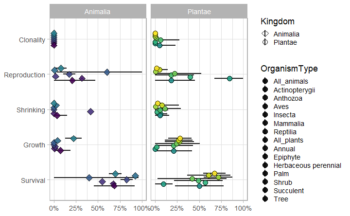

```r
rbind(
RelContrib_orgType,
RelContrib_df%>%mutate(OrganismType =ifelse(Kingdom=="Animalia", "All_animals","All_plants")))%>%
  mutate(name = str_remove(name, "_SigElas"))%>%
  mutate(name=factor(name, levels = c("Cumulative","Survival", "Growth", "Shrinking", "Reproduction","Clonality")))%>%
  mutate(OrganismType=fct_relevel(OrganismType, "All_plants", "All_animals"))%>%
  # filter(Kingdom=="Plantae")%>%
  ggplot(.,aes(x=name,y=Relativemean))+
  geom_pointrange(position=position_dodge(0.4),
                  aes(ymin = pmax(Relativemean-SD, 0), ymax = pmin(Relativemean+SD, 1),
                      fill=OrganismType,shape=Kingdom, group=OrganismType),color="black",linewidth = 1,size= 1.1,alpha=.9)+
  ylab(NULL)+xlab(NULL)+
  scale_shape_manual(values=c(23,21))+
  scale_y_continuous(labels = scales::percent_format())+
  scale_fill_viridis_d()+
  #scale_color_viridis_d()+
  #guides(fill = guide_legend(override.aes=list(shape=c(23,21))))+
  # guides(
  #    alpha= "none",
  # fill = guide_legend(
  #    override.aes=list(shape=rep(c(23, 21),
  #                                length.out=nlevels(factor(RelContrib$OrganismType))), alpha=1)))+
  theme_light(base_size=18)+
  facet_grid(.~Kingdom,scales="free")+
  coord_flip()
```

```r
NA
NA
```

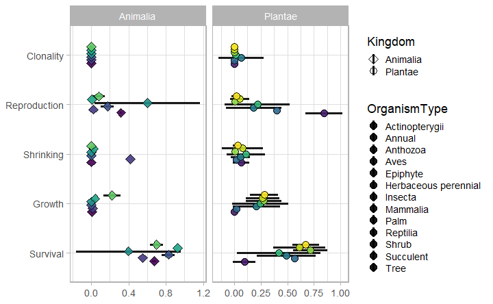

```r
RelContrib%>%
  group_by(Kingdom,name,OrganismType)%>%
  summarise(Relativemean=mean(RelativeProp),SD=sd(RelativeProp))%>%
#  pivot_wider(names_from=name,values_from = Relativemean)%>%
#  pivot_longer(!c(Kingdom,OrganismType), names_to="VR", values_to="RelativeProp")%>%
  mutate(name = str_remove(name, "_SigElas"))%>%
 # filter(Kingdom=="Plantae")%>%
  mutate(name=factor(name, levels = c("Cumulative","Survival", "Growth", "Shrinking", "Reproduction","Clonality")))%>%
  ggplot(.,aes(x=name,y=Relativemean,group=OrganismType))+
  geom_pointrange(position=position_dodge(0.4),
                  aes(ymin = Relativemean-SD, ymax = Relativemean+SD,
                      fill=OrganismType,shape=Kingdom),color="black",linewidth = 1.3,size= 1.1,alpha=.9)+
  ylab(NULL)+xlab(NULL)+
  scale_shape_manual(values=c(23,21))+
  scale_fill_viridis_d()+
  #scale_color_viridis_d()+
  #guides(fill = guide_legend(override.aes=list(shape=c(23,21))))+
  guides(
    alpha= "none",
 #  fill = guide_legend(override.aes=list(shape=c(23,21),alpha=1))
    )+
  theme_light(base_size=18)+
  facet_grid(.~Kingdom,scales="free")+
  coord_flip()
```

# 11. MCMCglmm results and tidy

Use `Data/MCMCglmm_output.rds` to check estimates and hypotheses testing

## 11.1 Loading GLMM outputs

```r
MCMCglmm_output<-readRDS("Data/MCMCglmm_output.rds")

lapply(MCMCglmm_output,names)

# Phylogenetic models
MCMCglmm_phylo_plants<-MCMCglmm_output$Phylogenetic_models[[1]]
MCMCglmm_phylo_animals<-MCMCglmm_output$Phylogenetic_models[[2]]

# Non-Phylogenetic (simple) models
MCMCglmm_simple_plants<-MCMCglmm_output$Simple_models[[1]]
MCMCglmm_simple_animals<-MCMCglmm_output$Simple_models[[2]]

rm(MCMCglmm_output)
```

## 11.2. Data Harmonization

## 11.2.1 As summary

Use this for data summary along the text

```r
Phylo_models_animals<-lapply(MCMCglmm_phylo_animals,function(inner_list) summary(inner_list))
Phylo_models_plants<-lapply(MCMCglmm_phylo_plants,function(inner_list) summary(inner_list))

Simple_models_animals<-lapply(MCMCglmm_simple_animals,function(inner_list) summary(inner_list))
Simple_models_plants<-lapply(MCMCglmm_simple_plants,function(inner_list) summary(inner_list))


Phylo_models_animals_coefs<-lapply(Phylo_models_animals,function(inner_list) inner_list[[5]])
Phylo_models_plants_coefs<-lapply(Phylo_models_plants,function(inner_list) inner_list[[5]])

Simple_models_animals_coefs<-lapply(Simple_models_animals,function(inner_list) inner_list[[5]])
Simple_models_plants_coefs<-lapply(Simple_models_plants,function(inner_list) inner_list[[5]])


Phylo_models_animals_coefs<-lapply(Phylo_models_animals_coefs,as.data.frame)
Phylo_models_plants_coefs<-lapply(Phylo_models_plants_coefs,as.data.frame)

Simple_models_animals_coefs<-lapply(Simple_models_animals_coefs,as.data.frame)
Simple_models_plants_coefs<-lapply(Simple_models_plants_coefs,as.data.frame)


Phylo_models_df_plants<-lapply(Phylo_models_plants_coefs,rownames_to_column, var = "Statistics")%>%
  Map(cbind, Trait = names(.),Taxa="Plants", Model="Phylo", .)%>%do.call(rbind,.)

Phylo_models_df_animals<-lapply(Phylo_models_animals_coefs,rownames_to_column, var = "Statistics")%>%
  Map(cbind, Trait = names(.),Taxa="Animals",Model="Phylo", .)%>%do.call(rbind,.)


Simple_models_df_plants<-lapply(Simple_models_plants_coefs,rownames_to_column, var = "Statistics")%>%
  Map(cbind, Trait = names(.),Taxa="Plants", Model="Simple", .)%>%do.call(rbind,.)

Simple_models_df_animals<-lapply(Simple_models_animals_coefs,rownames_to_column, var = "Statistics")%>%
  Map(cbind, Trait = names(.),Taxa="Animals",Model="Simple", .)%>%do.call(rbind,.)



GLMMs_df<-rbind(Phylo_models_df_plants,Phylo_models_df_animals,
                Simple_models_df_plants,Simple_models_df_animals)


colnames(GLMMs_df)<-c("Trait","Taxa","Model","Statistics","post.mean","low95","high95","eff.samp","pMCMC")


#---------------------------------------------------------------------------------------------------
# -----  SUMMARY SINTHESIS  -----
#---------------------------------------------------------------------------------------------------

GLMMs_df_summary<-GLMMs_df%>%
  mutate(sig=ifelse(pMCMC<=0.05,"Sig","Non-Sig"))%>%
#  filter(pMCMC<=0.1)%>%
  filter(Statistics!="(Intercept)")
```

### Plants

```r
# PLANTs x Cumulative only
GLMMs_df_summary%>%
  filter(Taxa=="Plants" & Trait == "Cumulative_SigElas")%>%
  group_by(Trait)


# By vital rates - Plants & Animals
GLMMs_df_summary%>%
  filter(Taxa=="Plants" & !c(Trait %in% c("Cumulative_SigElas","Buffmx")))%>%
  group_by(Trait)%>%group_split()
```

### Animals

```r
# PLANTs x Cumulative only
GLMMs_df_summary%>%
  filter(Taxa=="Animals" & Trait == "Cumulative_SigElas")%>%
  group_by(Trait)


# By vital rates - Plants & Animals
GLMMs_df_summary%>%
  filter(Taxa=="Animals" & !c(Trait %in% c("Cumulative_SigElas","Buffmx")))%>%
  group_by(Trait)%>%group_split()
```

## 11.2.2 Posterior distribution

Better for figures.

```r
Phylo_posterior_animals<-lapply(MCMCglmm_phylo_animals,function(inner_list) data.frame(inner_list$Sol,Taxa="Animals",Model="Phylo"))
Phylo_posterior_plants<-lapply(MCMCglmm_phylo_plants,function(inner_list) data.frame(inner_list$Sol,Taxa="Plants",Model="Phylo"))

Simple_posterior_animals<-lapply(MCMCglmm_simple_animals,function(inner_list) data.frame(inner_list$Sol,Taxa="Animals",Model="Simple"))
Simple_posterior_plants<-lapply(MCMCglmm_simple_plants,function(inner_list) data.frame(inner_list$Sol,Taxa="Plants",Model="Simple"))

Posterior_data<-rbind(
  do.call(rbind,Phylo_posterior_animals),
  do.call(rbind,Phylo_posterior_plants),
  do.call(rbind,Simple_posterior_animals),
  do.call(rbind,Simple_posterior_plants))%>%
  rownames_to_column(., var = "VAR")%>%
  separate(VAR,c("Trait"))%>%
  pivot_longer(!c(Trait,Taxa,Model),values_to="Values",names_to="Variables")%>%
  mutate(Variables=ifelse(Variables=="LHPC.1.LHPC.2","LHPC.1:LHPC.2",Variables))%>%
  mutate(Variables=ifelse(Variables=="ClimPC.1.ClimPC.2","ClimPC.1:ClimPC.2",Variables))%>%
  as_tibble()%>%
  filter(Variables!="X.Intercept.")

Posterior_data<-left_join(Posterior_data,
                          GLMMs_df%>%separate(Trait,"Trait"),
                          by=c("Trait","Taxa","Model","Variables"="Statistics"))%>%
  mutate(sig=ifelse(pMCMC<=0.05,"Sig","Non-Sig"))

Posterior_data%>%as_tibble()
```

## 11.3. GGPLOT Posterior distribution

### Code

Code only

```r
ggplot_posteriors<-Posterior_data%>%
  filter(Trait!="Buffmx")%>%
  ggplot(.,aes(x=Variables,y=Values,group=Model))+
  geom_hline(yintercept=0,linetype=2,color="grey50",linewidth=1.4)+
  stat_pointinterval(position=position_dodge(.5),.width = c(.66, .95),
                     aes(x = Variables,color=sig,shape=Model,fill=Model,alpha=sig))+
  scale_alpha_manual(values=c(.2,1))+
  scale_fill_manual(values=c("#da1438","#a783ce"))+
  scale_color_manual(values=c("grey30","black"))+
  scale_shape_manual(values=c(21,21))+
  xlab("Variables")+ylab("Posterior distribution")+
  ggh4x::facet_grid2(Trait~Taxa,scales="free_x",independent = "x")+
  theme_minimal(base_size=16)+coord_flip()+
  theme(
    #axis.text.x = element_text(angle = 45, hjust=1),
    legend.position="top")+
  guides(shape = guide_legend(override.aes = list(size = 5)))

ggplot_posteriors_vr<-ggplot_posteriors_cumu<-ggplot_posteriors

ggplot_posteriors_cumu$data<-filter(ggplot_posteriors$data,Taxa=="Plants" & Trait == "Cumulative")
ggplot_posteriors_vr$data<-filter(ggplot_posteriors$data,Taxa=="Plants" & Trait != "Cumulative")
```

### Posteriors All (plants & animals)

```r
# All vital rates + cumulative + All taxa
ggplot_posteriors
```

### Cumulative

```r
#  cumulative  & Plants only
ggplot_posteriors_cumu
```

### Vital rates

```r
#  cumulative vr & Plants only
ggplot_posteriors_vr
```

# 12. Estimating Phylogenetic signal

## 11.1. Create an anxiliary function Creates the new anxilliary function `my.fake.lamb`.

This function was created based on Garamszegi (2014)

```r
my.fake.lamb<-function(model){
  out =  model$VCV[,"phylo"]/
    (model$VCV[,"phylo"]+
       #            model$VCV[,"species"]+
       model$VCV[,"units"])
  mean.Lambda=mean(out)
  SE.lambda=(sd(out)/sqrt(length(out)))
  return(out)
}
```

## 12.2. Estimating phylogenetic signal for all models

Code below use `my.fake.lamb` to estimate phylogenetic signal for all models in a list.

package `ggridges` is necessary. Dependency for `geom_density_ridges`

```r
#InterestingVars<-c("Survival","Growth","Shrinking","Reproduction","Clonality","Buffmx","Cumulative")
traits<-c("Reproduction_SigElas", "Growth_SigElas", "Shrinking_SigElas",  "Clonality_SigElas", "Survival_SigElas",
          "Cumulative_SigElas","Buffmx")

#lapply(MCMCglmm_phylo_animals,function(inner_list) inner_list$VCV)

Phylo_signal_animals<-lapply(MCMCglmm_phylo_animals,function(inner_list) as.data.frame(my.fake.lamb(inner_list)))%>%
  do.call(cbind,.)

Phylo_signal_plants<-lapply(MCMCglmm_phylo_plants,function(inner_list) as.data.frame(my.fake.lamb(inner_list)))%>%
  do.call(cbind,.)

colnames(Phylo_signal_animals)<-str_split_i(traits, "_", 1)
colnames(Phylo_signal_plants)<-str_split_i(traits, "_", 1)

Phylo_signal_df<-rbind(
  data.frame(Phylo_signal_plants,Taxa="Plants"),
  data.frame(Phylo_signal_animals,Taxa="Animals"))%>%
  pivot_longer(!Taxa,names_to="Trait",values_to="Values")

Phylo_signal_df%>%
  group_by(Taxa,Trait)%>%
  summarise(Mean=mean(Values),
            SD=sd(Values),
            N=n(),
            gaussianCI=1.96*(SD/sqrt(N)),
            lower95=quantile(Values,.025),
            higher95=quantile(Values,.975))
```

## 12.3. Comparing phylogenetic signal

without significant correlation between phylogenetic signal and contribution to buffering capacity

```r
# Summarise phylogenetic signal
Phylo_summary <- Phylo_signal_df %>%
  filter(!(Trait %in% c("Cumulative","Buffmx")))%>%
  group_by(Taxa,Trait) %>%
  summarise(
    MEDIAN = median(Values),
    SD = sd(Values),
    SE = SD / sqrt(n()) )%>%
  mutate(Trait=factor(Trait,levels = c("Survival", "Growth", "Shrinking", "Reproduction", "Clonality")))

# Merge phylogenetic signal (summarized) with relative contribution
phylo_buffer_df<-left_join(
Phylo_summary%>%mutate(Kingdom=ifelse(Taxa=="Animals", "Animalia", "Plantae")),
RelContrib_df%>%mutate(name = str_remove(name, "_SigElas")),
by=c("Trait" = "name", "Kingdom"),suffix = c(".phylo", ".buffer"))%>%
  select(-Kingdom)

cor.test(method="spearman",
  filter(phylo_buffer_df,Taxa=="Plants")$MEDIAN,
filter(phylo_buffer_df,Taxa=="Plants")$Relativemean
)
```

Detailed values for plants

```r
Phylo_summary%>%filter(Taxa=="Plants")
```

### Bar Plot

#### Plants

```r
Phylo_summary%>%
  filter(Taxa=="Plants")%>%
ggplot(., aes(x = Trait, y = MEDIAN, fill = Taxa)) +
  geom_bar(stat = "identity", position = position_dodge()) +  # Barras com transparência leve
  geom_pointrange(aes(ymin = MEDIAN - SD, ymax=pmin(MEDIAN + SD, 1)),
                  position = position_dodge(width = 0.9), color = "black", size = 0.8) +
  scale_fill_manual(values=c("#1f9a59"))+
  labs(x = NULL,
       y = "Phylogenetic signal \n (Pagel's lambda)") +
  theme_minimal(base_size=18)+
  theme(legend.position="none",
        panel.spacing = unit(2, "lines"))
```

#### Plants & Animals

```r
Phylo_summary%>%
ggplot(., aes(x = Trait, y = MEDIAN, fill = Taxa)) +
  geom_bar(stat = "identity", position = position_dodge()) +  # Barras com transparência leve
  geom_pointrange(aes(ymin = MEDIAN - SD, ymax=pmin(MEDIAN + SD, 1)),
                  position = position_dodge(width = 0.9), color = "black", size = 0.8) +
  scale_fill_manual(values=c("#144375","#1f9a59"))+
  labs(x = NULL,
       y = "Phylogenetic signal \n (Pagel's lambda)") +
  theme_minimal(base_size=18)+
  theme(legend.position="top",
        panel.spacing = unit(2, "lines"))
```

### Phylo x buffer plot

```r
phylo_buffer_df%>%
  ggplot(data=.,aes(x=Relativemean,y=MEDIAN))+
  geom_point()+
  geom_pointrange(aes(ymin=MEDIAN-SD.phylo,ymax=MEDIAN+SD.phylo))+
  facet_grid(.~Taxa)+
  labs(x="Relative contribution to buffering capacity",
       y="Phylogenetic signal")
```

### Animals & Plants data

```r
Phylo_summary
```

### Animals & Plants plot

```r
# PLOT
Phylo_signal_df%>%
  group_by(Taxa,Trait)%>%
  filter(Trait!="Buffmx")%>%
  filter(!(Values>quantile(Values,.975)))%>%
  filter(!(Values<quantile(Values,.025)))%>%
  ggplot(.,aes(x=Values, y =  fct_rev(Trait),fill=Taxa))+
  #geom_density_ridges(aes(fill = Taxa), rel_min_height = 0.01)+
  ggridges::geom_density_ridges(aes(fill=Taxa))+
  xlab("Pagel's lambda )")+
  scale_fill_manual(values=c("#144375","#1f9a59"))+
  theme_minimal(base_size=16)+
  ylab(NULL)+
  theme(axis.text.y=element_blank(),legend.position="top",
        panel.spacing = unit(2, "lines"))+
  facet_grid(Trait~.,scale="free_y")
```

# References

Bernard, Connor, Gabriel Silva Santos, Jacques A. Deere, Roberto Rodriguez-Caro, Pol Capdevila, Erik Kusch, Samuel J. L. Gascoigne, John Jackson, and Roberto Salguero-Gómez. 2023. “MOSAIC - A Unified Trait Database to Complement Structured Population Models.” *Scientific Data* 10 (1): 335. https://doi.org/10.1038/s41597-023-02070-w.

Garamszegi, László Zsolt. 2014. *Modern Phylogenetic Comparative Methods and Their Application in Evolutionary Biology*.

Jones, Owen R., Patrick Barks, Iain Stott, Tamora D. James, Sam Levin, William K. Petry, Pol Capdevila, et al. 2022. “Rcompadre and RageTwo R Packages to Facilitate the Use of the COMPADRE and COMADRE Databases and Calculation of Life-History Traits from Matrix Population Models.” *Methods in Ecology and Evolution* 13 (4): 770–81. https://doi.org/10.1111/2041-210X.13792.